# Lab Assignment Seven: Recurrent Network Architectures

Team members: Long Zhang,Qinyu Chen, Zhengwen Zhang

## Business understanding

In this lab, We will select a text SMS dataset and perform spam message predictions, We will evaluate a recurrent architecture(LSTM and GRU) and tune hyper-parameters. The SMS Spam Collection is available from kaggle, the downloaded file is in csv format, each line of the SMS is in txt format. The corpus(dataset) is a set of SMS tagged messages that have been collected for free from internet for SMS Spam research. The SMS messages are in English, they are categorized as ham (legitimate) or spam.We think it is a perfect dataset to perform binary classification in Rrcurrent Network.

We think wireless provider will be interested in our prediction model. As we all know that consumers receive tons of spam SMS everyday, this will even cost some charges for some prepaid users in the US, spam SMS messages can also lead to financial loss, unlike legimigate SMS, spam messages can not be unsubscribed most of the time. Based on the results of our model, Service provider can selectively block or filter these messages in the backend before delivering the messages to customers, thus improving quality of mobile services.App developer may also be interested in our model, they can develop apps that implement some algorithms based on our model, end users can block or filter spam SMSs as well.

Data source: https://www.kaggle.com/uciml/sms-spam-collection-dataset

## 1. Preparation

Reference: https://github.com/eclarson/MachineLearningNotebooks/blob/master/13.%20RNN%20Basics.ipynb

```python
import os
import itertools
import sys
import time
import numpy as np # linear algebra
import pandas as pd # data processing, CSV file I/O (e.g. pd.read_csv)
from tqdm import tqdm
import matplotlib.pyplot as plt
import pickle
import seaborn as sns
import math
import random
from sklearn.model_selection import train_test_split
from sklearn import metrics
from sklearn import metrics as mt

import keras
from keras.utils.vis_utils import model_to_dot
from keras.preprocessing.text import Tokenizer
from keras.preprocessing.sequence import pad_sequences
from keras.utils.np_utils import to_categorical
from keras.layers import Dense, Input, LSTM, Embedding, Dropout, Activation, CuDNNGRU, Conv1D, GRU
from keras.layers import Bidirectional, GlobalMaxPool1D, Flatten, MaxPooling1D
from keras.models import Model
from keras.models import Sequential, load_model
from keras import initializers, regularizers, constraints, optimizers, layers
```

### 1.1 Define and prepare your class variables.

```python
#df = pd.read_csv("/Users/terrence/desktop/SPAM.csv")
df = pd.read_csv("/Users/chenqinyu/desktop/SPAM.csv")
# df = pd.read_csv(r"E:\Dropbox\smu\CSE7324\assignment\Lab7\SPAM.csv")
print("Train shape : ", df.shape)
```

```
Train shape :  (5572, 2)
```

```python
df["Category"].replace({"ham": 0 , "spam":1 }, inplace=True)
```

```python
df["Category"].value_counts()
```

```
0    4825
1     747
Name: Category, dtype: int64
```

```python
## fill up the missing values
df_X = df["Message"].fillna("_na_").values
df_X
```

```
array(['Go until jurong point, crazy.. Available only in bugis n great world la e buffet... Cine there got amore wat...',
       'Ok lar... Joking wif u oni...',
       "Free entry in 2 a wkly comp to win FA Cup final tkts 21st May 2005. Text FA to 87121 to receive entry question(std txt rate)T&C's apply 08452810075over18's",
       ..., 'Pity, * was in mood for that. So...any other suggestions?',
       "The guy did some bitching but I acted like i'd be interested in buying something else next week and he gave it to us for free",
       'Rofl. Its true to its name'], dtype=object)
```

```python
## Get the target values
df_y = df['Category'].values
```

#### Methods of tokenization in your dataset as well as decisions to force a specific length of sequence

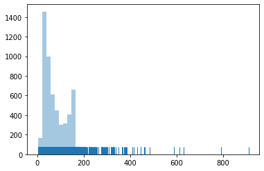

```python
length=[]
for e in df.Message:
    length.append(len(e))
sns.distplot(length, kde=False, rug=True);
```

```python
NUM_TOP_WORDS = None # how many unique words to use (i.e num rows in embedding vector)
MAX_ART_LEN = 400 # max number of words in a question to use

tokenizer = Tokenizer(num_words=NUM_TOP_WORDS)
tokenizer.fit_on_texts(df_X)
sequences = tokenizer.texts_to_sequences(df_X)

word_index = tokenizer.word_index
NUM_TOP_WORDS = len(word_index) if NUM_TOP_WORDS==None else NUM_TOP_WORDS
top_words = min((len(word_index),NUM_TOP_WORDS))
print('Found %s unique tokens. Distilled to %d top words.' % (len(word_index),top_words))

X = pad_sequences(sequences, maxlen=MAX_ART_LEN)

y_ohe = keras.utils.to_categorical(df_y)
print('Shape of data tensor:', X.shape)
print('Shape of label tensor:', y_ohe.shape)
print(np.max(X))
```

```
Found 9004 unique tokens. Distilled to 9004 top words.
Shape of data tensor: (5572, 400)
Shape of label tensor: (5572, 2)
9004
```

The tokenizer class from Keras will convert a text document into a list of integers where each integer represents a word. In this representation, the integer is called a token. In our implementation, we use every word found in all of the documents. We also found the number of words from each document to only the first 400, only very few samples has the extreme long length, we choose to ignore those few extremes.If a document does not have 400 words, then it is zero-padded on the left. The tokens also only represent words-- the punctuation is completely scrubbed from the documents.

### 1.2 Evaluation Metric

Let's see our case, we want to predict what kind of a given text would be -- it's spam or ham? it's a binary classification probelm, and also we notice that the size of each class is imbalanced ( ham size is 4825, spam size is 747).

In this particular imbalanced class problem, if we don't choose a more objective metrics, if the penalty for small and large data when replacing the training model will be the same, which will lead to more sensitive to the data, and the smaller sample size will cause badly prediction bias. How can we deal with this deviation, so that the model has good prediction results for large and small categories?

first we have the traditional metric--Accuracy / precision: precision directly reflects the performance of our machine learning model. The higher the score, the higher the accuracy of the prediction.

second we have Recall rate: Although the accuracy rate is very common, it also has great limitations when facing the problem of class imbalance. Note that recall rate is actually TPR (true positive rate), which is imapcted by the ratio between the predicted positive sample and the true positive sample.

Through the previous analysis, we can find that the precision rate and the recall rate have their own respective emphases, resulting in completely different evaluation results for the same problem, so whether there is a scoring method that can fully consider Accuracy and recall rate, so as to comprehensively evaluate various machine learning models (including class imbalance problems)? The answer is the F1 score.

F1 score formula is fairly simple ---- ( F1 = (2 *PRE* RECALL) / (PRE + RECALL)). just take the precision rate and recall rate calculated into the f1 formula, the we could get the f1 score.

Generally speaking, especially in the problem of class imbalance, we think that the higher the F1 score, the better the model performance.

referece sorce: python machine learning 3rd

Guglielmocamporese. “Macro F1-Score Keras.” Kaggle, Kaggle, 20 Oct. 2018, https://www.kaggle.com/guglielmocamporese/macro-f1-score-keras.

```python
import keras.backend as K
import tensorflow as tf
from tensorflow import math

def f1(y_true, y_pred):
    y_pred = K.round(y_pred)
    tp = K.sum(K.cast(y_true*y_pred, 'float'), axis=0)
    # tn = K.sum(K.cast((1-y_true)*(1-y_pred), 'float'), axis=0)
    fp = K.sum(K.cast((1-y_true)*y_pred, 'float'), axis=0)
    fn = K.sum(K.cast(y_true*(1-y_pred), 'float'), axis=0)

    p = tp / (tp + fp + K.epsilon())
    r = tp / (tp + fn + K.epsilon())

    f1 = 2*p*r / (p+r+K.epsilon())
    f1 = tf.where(tf.math.is_nan(f1), tf.zeros_like(f1), f1)
    return K.mean(f1)
```

### 1.3 Train and Test set Split

Then we split our dataset into 80% training data and 20% testing data. For the part of investigating the different recurrent neural network architecture, we used 80% training data to train the model and 20% testing data to validation the model. But after chooseing the best model and the best hyper-parameter, we will use 10-fold cross validation to train and investigate the general performance of the chosen model like we talked about.

```python
# Split it into train / test subsets
X = np.array(X)
y = np.array(df_y)
X_train, X_test, y_train, y_test = train_test_split(X, y, test_size=0.2,
                                                            stratify=df_y,
                                                            random_state=42,
                                                           )
NUM_CLASSES=2

y_train_ohe = keras.utils.to_categorical(y_train, NUM_CLASSES)
y_test_ohe = keras.utils.to_categorical(y_test, NUM_CLASSES)

print(X_train.shape,y_train_ohe.shape)
print(X_test.shape,y_test_ohe.shape)
print(np.sum(y_train_ohe,axis=0))
```

```
(4457, 400) (4457, 2)
(1115, 400) (1115, 2)
[3859.  598.]
```

# 2. Modeling

# LSTM

```python
%%time
EMBED_SIZE = 100
# the embed size should match the file you load glove from
embeddings_index = {}
#f = open('/Users/terrence/desktop/glove.6B.100d.txt')
#f = open(r'E:\Dropbox\smu\CSE7324\assignment\Lab7\glove.6B.100d.txt')

f = open('/Users/chenqinyu/Desktop/glove.6B/glove.6B.100d.txt', encoding='utf-8')

# save key/array pairs of the embeddings
#  the key of the dictionary is the word, the array is the embedding
for line in f:
    values = line.split()
    word = values[0]
    coefs = np.asarray(values[1:], dtype='float32')
    embeddings_index[word] = coefs
f.close()

print('Found %s word vectors.' % len(embeddings_index))

# now fill in the matrix, using the ordering from the
#  keras word tokenizer from before
embedding_matrix = np.zeros((len(word_index) + 1, EMBED_SIZE))
for word, i in word_index.items():
    embedding_vector = embeddings_index.get(word)
    if embedding_vector is not None:
        # words not found in embedding index will be all-zeros.
        embedding_matrix[i] = embedding_vector

print(embedding_matrix.shape)
```

```
Found 400000 word vectors.
(9005, 100)
CPU times: user 10.5 s, sys: 303 ms, total: 10.8 s
Wall time: 10.3 s
```

```python
embedding_layer = Embedding(len(word_index) + 1,
                            EMBED_SIZE,
                            weights=[embedding_matrix],
                            input_length=MAX_ART_LEN,
                            trainable=False)
```

```python
from keras.models import Sequential
from keras.layers import Dense
from keras.layers import LSTM

rnn = Sequential()
rnn.add(embedding_layer)
rnn.add(LSTM(32,dropout=0.5, recurrent_dropout=0.5,activation='relu',return_sequences=True))
rnn.add(GlobalMaxPool1D())
#rnn.add(LSTM(128,dropout=0.2, recurrent_dropout=0.2,activation='relu'))
rnn.add(Dense(NUM_CLASSES, activation='sigmoid'))
rnn.compile(loss='binary_crossentropy',
              optimizer= 'adam',
              metrics=['accuracy',f1])
print(rnn.summary())
```

```
WARNING:tensorflow:From <ipython-input-9-538149ba5911>:16: add_dispatch_support.<locals>.wrapper (from tensorflow.python.ops.array_ops) is deprecated and will be removed in a future version.
Instructions for updating:
Use tf.where in 2.0, which has the same broadcast rule as np.where
Model: "sequential_1"
_________________________________________________________________
Layer (type)                 Output Shape              Param #
=================================================================
embedding_1 (Embedding)      (None, 400, 100)          900500
_________________________________________________________________
lstm_1 (LSTM)                (None, 400, 32)           17024
_________________________________________________________________
global_max_pooling1d_1 (Glob (None, 32)                0
_________________________________________________________________
dense_1 (Dense)              (None, 2)                 66
=================================================================
Total params: 917,590
Trainable params: 17,090
Non-trainable params: 900,500
_________________________________________________________________
None
```

### Cross validation

Then we use 10-fold cross validation to train and investigate the general performance of the chosen model like we talked about

```python
from matplotlib import pyplot as plt
from sklearn.model_selection import StratifiedKFold

n_folds = 10
skf = StratifiedKFold(n_splits=n_folds)

cv_training_f1_score = []
cv_training_loss = []

cv_val_f1_score = []
cv_val_loss = []


iternum = 1
for train_indices, val_indices in skf.split(X_train, y_train):
    X_tmp_train = X_train[train_indices]
    y_tmp_train = y_train_ohe[train_indices]

    X_tmp_val = X_train[val_indices]
    y_tmp_val = y_train_ohe[val_indices]
    history = rnn.fit(X_tmp_train, y_tmp_train, validation_data=(X_tmp_val,y_tmp_val), epochs=10, batch_size=64)
    # save the performance data of different training and validation set

    cv_training_f1_score.append(history.history.get('f1'))
    cv_val_f1_score.append(history.history.get('val_f1'))

    cv_training_loss.append(history.history.get('loss'))
    cv_val_loss.append(history.history.get('val_loss'))
```

```
WARNING:tensorflow:From /opt/anaconda3/lib/python3.7/site-packages/keras/backend/tensorflow_backend.py:422: The name tf.global_variables is deprecated. Please use tf.compat.v1.global_variables instead.

Train on 4011 samples, validate on 446 samples
Train on 4011 samples, validate on 446 samples
Train on 4011 samples, validate on 446 samples
Train on 4011 samples, validate on 446 samples
Train on 4011 samples, validate on 446 samples
Train on 4011 samples, validate on 446 samples
Train on 4011 samples, validate on 446 samples
Train on 4011 samples, validate on 446 samples
Train on 4012 samples, validate on 445 samples
Train on 4013 samples, validate on 444 samples
```

In order to better understand relationship between trainning and validation sets, we do visualization here.

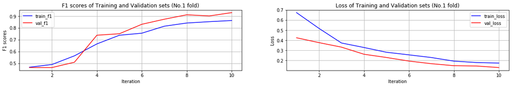

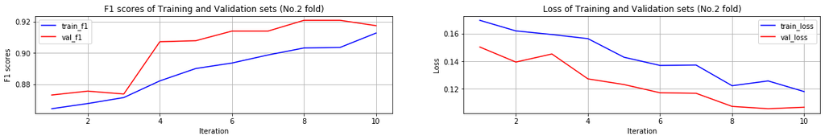

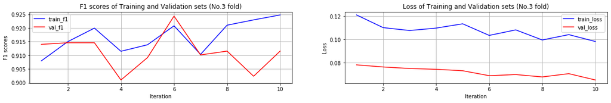

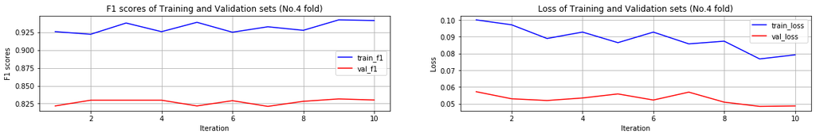

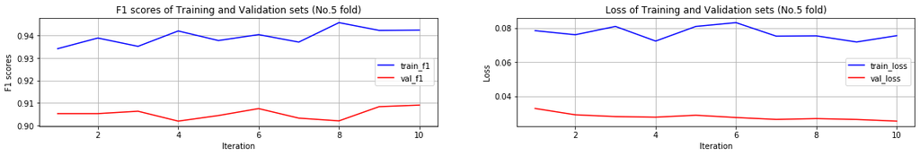

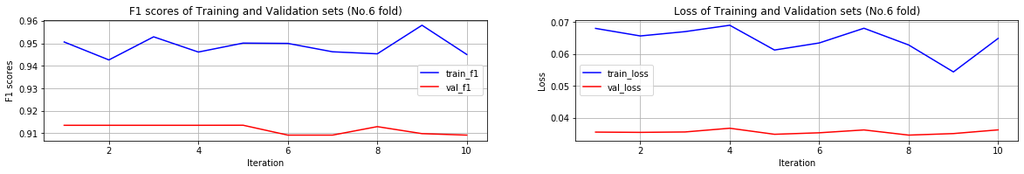

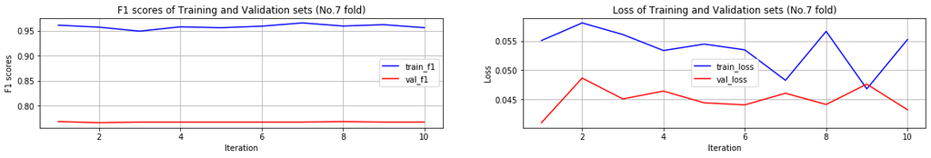

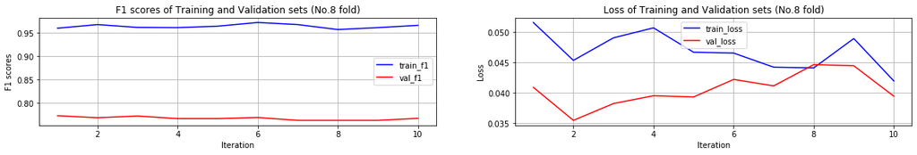

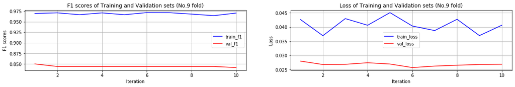

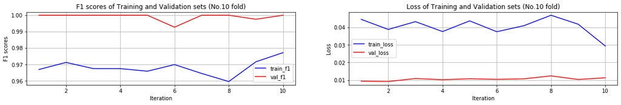

```python
# there are 10 folds, so there are 10 groups of data
for i in range(0, len(cv_training_f1_score)):
    iteration = range(1,len(cv_training_f1_score[i])+1)
    plt.figure(figsize=(20,30))
    plt.subplot(10,2,1)
    plt.plot(iteration, cv_training_f1_score[i], linestyle='-', color='blue', label='train_f1')
    plt.plot(iteration, cv_val_f1_score[i], linestyle='-', color='red', label='val_f1')
    plt.grid()
    plt.legend()
    plt.xlabel('Iteration')
    plt.ylabel('F1 scores')
    plt.title('F1 scores of Training and Validation sets (No.%.0f fold)' % (i+1))

    plt.subplot(10,2,2)
    plt.plot(iteration, cv_training_loss[i], linestyle='-', color='blue', label='train_loss')
    plt.plot(iteration, cv_val_loss[i], linestyle='-', color='red', label='val_loss')
    plt.grid()
    plt.legend()
    plt.xlabel('Iteration')
    plt.ylabel('Loss')
    plt.title('Loss of Training and Validation sets (No.%.0f fold)' % (i+1))
```

```python
def confusion_rnn(rnn, X_test, y_test_ohe, title):
    yhat = np.argmax(rnn.predict(X_test), axis=1)
    y_test = np.argmax(y_test_ohe, axis = 1)
    cm = metrics.confusion_matrix(y_test, yhat)
    cm = cm/np.sum(cm,axis=1)[:,np.newaxis]
    acc = metrics.accuracy_score(y_test, yhat)
    f1 = metrics.f1_score(y_test, yhat, average="macro")
    plt.title("Using " + str(title) + ": " +' Acc: {:.4f}'.format(acc) + ' F1: {:.4f}'.format(f1))
    sns.heatmap(cm, annot=True, fmt='.2f')
    plt.show()
```

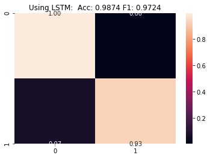

```python
confusion_rnn(rnn, X_test, y_test_ohe, 'LSTM')
```

TP for LSTM model is much higher than FP(close to 0), so it is better to choose F1 as metrix rather than accuracy.

## Reference for threshold_search

Sudalairajkumar. “A Look at Different Embeddings.!” Kaggle, Kaggle, 8 Nov. 2018, https://www.kaggle.com/sudalairajkumar/a-look-at-different-embeddings.

```python
#Search for the threshold for best f1
def threshold_search(y_true, y_proba):
    best_threshold = 0
    best_score = 0
    for threshold in tqdm([i * 0.01 for i in range(100)], disable=True):
        score = metrics.f1_score(y_true, (y_proba> threshold).astype(int),average = "macro")
        if score > best_score:
            best_threshold = threshold
            best_score = score
    search_result = {'threshold': best_threshold, 'f1': best_score}
    return search_result


test_pred = np.argmax(rnn.predict([X_test], batch_size=512, verbose=1),axis=1)
y_test = np.argmax(y_test_ohe,axis=1)
search_result = threshold_search(y_test, test_pred)
```

```python
search_result
```

```
{'threshold': 0.0, 'f1': 0.9724154261560427}
```

```python
y_test = np.argmax(y_test_ohe,axis=1)
#All the f1
test_pred = np.argmax(rnn.predict(X_test),axis=1)
for thresh in np.arange(0.6, 1.01, 0.01):
    thresh = np.round(thresh, 2)
    print("F1 score at threshold {0} is {1}".format(thresh, metrics.f1_score(y_test, (test_pred > thresh).astype(int),average = "macro")))
```

```
F1 score at threshold 0.6 is 0.9724154261560427
F1 score at threshold 0.61 is 0.9724154261560427
F1 score at threshold 0.62 is 0.9724154261560427
F1 score at threshold 0.63 is 0.9724154261560427
F1 score at threshold 0.64 is 0.9724154261560427
F1 score at threshold 0.65 is 0.9724154261560427
F1 score at threshold 0.66 is 0.9724154261560427
F1 score at threshold 0.67 is 0.9724154261560427
F1 score at threshold 0.68 is 0.9724154261560427
F1 score at threshold 0.69 is 0.9724154261560427
F1 score at threshold 0.7 is 0.9724154261560427
F1 score at threshold 0.71 is 0.9724154261560427
F1 score at threshold 0.72 is 0.9724154261560427
F1 score at threshold 0.73 is 0.9724154261560427
F1 score at threshold 0.74 is 0.9724154261560427
F1 score at threshold 0.75 is 0.9724154261560427
F1 score at threshold 0.76 is 0.9724154261560427
F1 score at threshold 0.77 is 0.9724154261560427
F1 score at threshold 0.78 is 0.9724154261560427
F1 score at threshold 0.79 is 0.9724154261560427
F1 score at threshold 0.8 is 0.9724154261560427
F1 score at threshold 0.81 is 0.9724154261560427
F1 score at threshold 0.82 is 0.9724154261560427
F1 score at threshold 0.83 is 0.9724154261560427
F1 score at threshold 0.84 is 0.9724154261560427
F1 score at threshold 0.85 is 0.9724154261560427
F1 score at threshold 0.86 is 0.9724154261560427
F1 score at threshold 0.87 is 0.9724154261560427
F1 score at threshold 0.88 is 0.9724154261560427
F1 score at threshold 0.89 is 0.9724154261560427
F1 score at threshold 0.9 is 0.9724154261560427
F1 score at threshold 0.91 is 0.9724154261560427
F1 score at threshold 0.92 is 0.9724154261560427
F1 score at threshold 0.93 is 0.9724154261560427
F1 score at threshold 0.94 is 0.9724154261560427
F1 score at threshold 0.95 is 0.9724154261560427
F1 score at threshold 0.96 is 0.9724154261560427
F1 score at threshold 0.97 is 0.9724154261560427
F1 score at threshold 0.98 is 0.9724154261560427
F1 score at threshold 0.99 is 0.9724154261560427
F1 score at threshold 1.0 is 0.4641999038923595
```

# GRU

The main hyperparemeters that we experimented with were dropout and recurrent dropout. Dropout refers to the fact that part of the neural network is not being trained on each iteration. We found that when dropout was more than 0.3, our performance began to get worse. We used the values 0.1, 0.2, and 0.5. We also experimented with the size of the unit as we used 32, 64, 128. However, we did not try every combination of size of unit with dropout values. However, we did find decent performance (speed and loss value) when size was 32.

```python
rnn_gru = Sequential()
rnn_gru.add(embedding_layer)
#rnn_gru.add(GRU(128,dropout=0.2, recurrent_dropout=0.2,activation='relu'))
rnn_gru.add(GRU(32,dropout=0.1, recurrent_dropout=0.1,activation='relu',return_sequences=True))
rnn_gru.add(GlobalMaxPool1D())
rnn_gru.add(Dense(NUM_CLASSES, activation='sigmoid'))
rnn_gru.compile(loss='binary_crossentropy',
              optimizer='adam',
              metrics=[f1])
print(rnn_gru.summary())
```

```
Model: "sequential_2"
_________________________________________________________________
Layer (type)                 Output Shape              Param #
=================================================================
embedding_1 (Embedding)      (None, 400, 100)          900500
_________________________________________________________________
gru_1 (GRU)                  (None, 400, 32)           12768
_________________________________________________________________
global_max_pooling1d_2 (Glob (None, 32)                0
_________________________________________________________________
dense_2 (Dense)              (None, 2)                 66
=================================================================
Total params: 913,334
Trainable params: 12,834
Non-trainable params: 900,500
_________________________________________________________________
None
```

### Cross validation

Then we use 10-fold cross validation to train and investigate the general performance of the chosen model like we talked about.

```python
from matplotlib import pyplot as plt
from sklearn.model_selection import StratifiedKFold
n_folds = 10
skf = StratifiedKFold(n_splits=n_folds)

cv_training_f1_score = []
cv_training_loss = []

cv_val_f1_score = []
cv_val_loss = []


iternum = 1
for train_indices, val_indices in skf.split(X_train, y_train):
    X_tmp_train = X_train[train_indices]
    y_tmp_train = y_train_ohe[train_indices]

    X_tmp_val = X_train[val_indices]
    y_tmp_val = y_train_ohe[val_indices]
    history = rnn_gru.fit(X_tmp_train, y_tmp_train, validation_data=(X_tmp_val,y_tmp_val), epochs=10, batch_size=64)
    # save the performance data of different training and validation set

    cv_training_f1_score.append(history.history.get('f1'))
    cv_val_f1_score.append(history.history.get('val_f1'))

    cv_training_loss.append(history.history.get('loss'))
    cv_val_loss.append(history.history.get('val_loss'))
```

```
Train on 4011 samples, validate on 446 samples
Train on 4011 samples, validate on 446 samples
Train on 4011 samples, validate on 446 samples
Train on 4011 samples, validate on 446 samples
Train on 4011 samples, validate on 446 samples
Train on 4011 samples, validate on 446 samples
Train on 4011 samples, validate on 446 samples
Train on 4011 samples, validate on 446 samples
Train on 4012 samples, validate on 445 samples
Train on 4013 samples, validate on 444 samples
```

In order to better understand relationship between trainning and validation sets, we do visualization here.

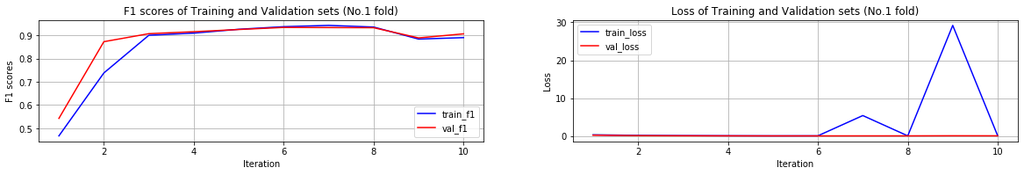

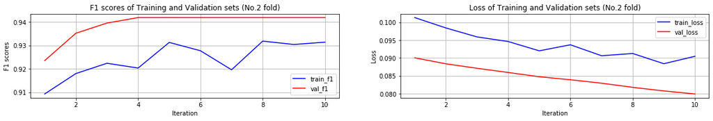

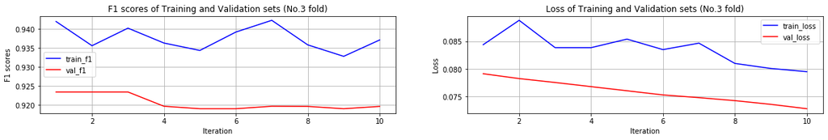

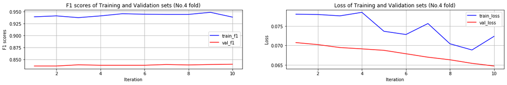

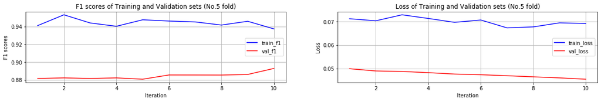

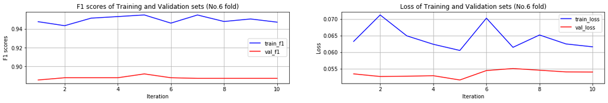

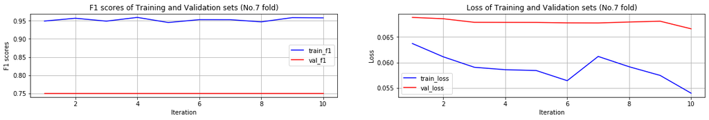

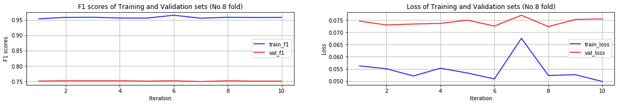

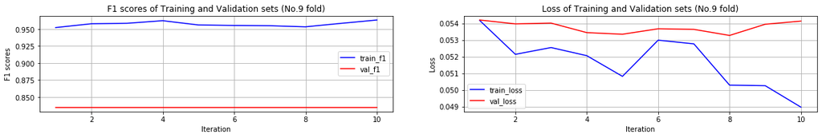

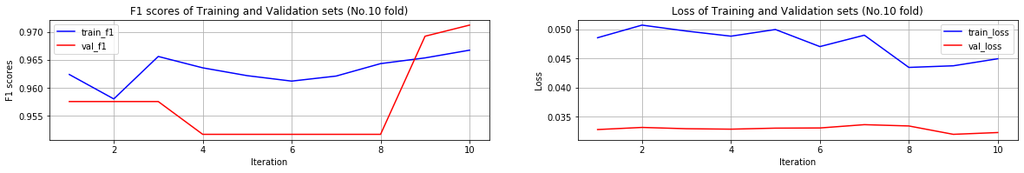

```python
# there are 10 folds, so there are 10 groups of data
for i in range(0, len(cv_training_f1_score)):
    iteration = range(1,len(cv_training_f1_score[i])+1)
    plt.figure(figsize=(20,30))
    plt.subplot(10,2,1)
    plt.plot(iteration, cv_training_f1_score[i], linestyle='-', color='blue', label='train_f1')
    plt.plot(iteration, cv_val_f1_score[i], linestyle='-', color='red', label='val_f1')
    plt.grid()
    plt.legend()
    plt.xlabel('Iteration')
    plt.ylabel('F1 scores')
    plt.title('F1 scores of Training and Validation sets (No.%.0f fold)' % (i+1))

    plt.subplot(10,2,2)
    plt.plot(iteration, cv_training_loss[i], linestyle='-', color='blue', label='train_loss')
    plt.plot(iteration, cv_val_loss[i], linestyle='-', color='red', label='val_loss')
    plt.grid()
    plt.legend()
    plt.xlabel('Iteration')
    plt.ylabel('Loss')
    plt.title('Loss of Training and Validation sets (No.%.0f fold)' % (i+1))
```

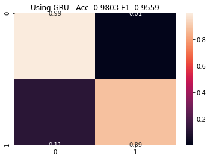

```python
confusion_rnn(rnn_gru, X_test, y_test_ohe, 'GRU')
```

```python
test_pred_gru = np.argmax(rnn_gru.predict([X_test], batch_size=128, verbose=1),axis=1)
search_result_gru = threshold_search(y_test, test_pred_gru)
```

```python
y_test = np.argmax(y_test_ohe,axis=1)
#All the f1
test_pred = np.argmax(rnn_gru.predict([X_test], batch_size=128, verbose=1),axis=1)
for thresh in np.arange(0.6, 1.01, 0.01):
    thresh = np.round(thresh, 2)
    print("F1 score at threshold {0} is {1}".format(thresh, metrics.f1_score(y_test, (test_pred > thresh).astype(int),average = "macro")))
```

```
F1 score at threshold 0.6 is 0.9558800253244698
F1 score at threshold 0.61 is 0.9558800253244698
F1 score at threshold 0.62 is 0.9558800253244698
F1 score at threshold 0.63 is 0.9558800253244698
F1 score at threshold 0.64 is 0.9558800253244698
F1 score at threshold 0.65 is 0.9558800253244698
F1 score at threshold 0.66 is 0.9558800253244698
F1 score at threshold 0.67 is 0.9558800253244698
F1 score at threshold 0.68 is 0.9558800253244698
F1 score at threshold 0.69 is 0.9558800253244698
F1 score at threshold 0.7 is 0.9558800253244698
F1 score at threshold 0.71 is 0.9558800253244698
F1 score at threshold 0.72 is 0.9558800253244698
F1 score at threshold 0.73 is 0.9558800253244698
F1 score at threshold 0.74 is 0.9558800253244698
F1 score at threshold 0.75 is 0.9558800253244698
F1 score at threshold 0.76 is 0.9558800253244698
F1 score at threshold 0.77 is 0.9558800253244698
F1 score at threshold 0.78 is 0.9558800253244698
F1 score at threshold 0.79 is 0.9558800253244698
F1 score at threshold 0.8 is 0.9558800253244698
F1 score at threshold 0.81 is 0.9558800253244698
F1 score at threshold 0.82 is 0.9558800253244698
F1 score at threshold 0.83 is 0.9558800253244698
F1 score at threshold 0.84 is 0.9558800253244698
F1 score at threshold 0.85 is 0.9558800253244698
F1 score at threshold 0.86 is 0.9558800253244698
F1 score at threshold 0.87 is 0.9558800253244698
F1 score at threshold 0.88 is 0.9558800253244698
F1 score at threshold 0.89 is 0.9558800253244698
F1 score at threshold 0.9 is 0.9558800253244698
F1 score at threshold 0.91 is 0.9558800253244698
F1 score at threshold 0.92 is 0.9558800253244698
F1 score at threshold 0.93 is 0.9558800253244698
F1 score at threshold 0.94 is 0.9558800253244698
F1 score at threshold 0.95 is 0.9558800253244698
F1 score at threshold 0.96 is 0.9558800253244698
F1 score at threshold 0.97 is 0.9558800253244698
F1 score at threshold 0.98 is 0.9558800253244698
F1 score at threshold 0.99 is 0.9558800253244698
F1 score at threshold 1.0 is 0.4641999038923595
```

### Adjust hyper-parameters of the networks as needed to improve generalization performance

Use different dropout and recurrent dropout list for LSTM and GRU

```python
type_list = [LSTM]
units_list = [32, 64]
dropout_list = [0.4, 0.5]
recurrent_dropout_list = [0.4,0.5]
rnn_list = {}

for (t, u, d, r) in itertools.product(type_list, units_list, dropout_list, recurrent_dropout_list):
    rnn = Sequential()
    rnn.add(embedding_layer)
    rnn.add(t(u,dropout=d, recurrent_dropout=r,activation='relu',return_sequences=True))
    rnn.add(GlobalMaxPool1D())
    #rnn.add(LSTM(128,dropout=0.2, recurrent_dropout=0.2,activation='relu'))
    rnn.add(Dense(NUM_CLASSES, activation='sigmoid'))
    rnn.compile(loss='binary_crossentropy',
              optimizer='adam',
              metrics=['accuracy'])

    rnn.fit(X_train, y_train_ohe, validation_data=(X_test, y_test_ohe), epochs=10, batch_size=128)
    yhat = np.argmax(rnn.predict(X_test), axis=1)
    y_test = np.argmax(y_test_ohe, axis = 1)
    acc = metrics.accuracy_score(y_test, yhat)
    f1 = metrics.f1_score(y_test, yhat, average="macro")
    log = "{} (unit={}, dropout={}, recurrent={}): Acc={}, F1={} ".format(t, u, d, r, acc, f1)
    rnn_list[log] = rnn
    print(log)
```

```
Train on 4457 samples, validate on 1115 samples
<class 'keras.layers.recurrent.LSTM'> (unit=32, dropout=0.4, recurrent=0.4): Acc=0.9668161434977578, F1=0.9222907236729334
Train on 4457 samples, validate on 1115 samples
<class 'keras.layers.recurrent.LSTM'> (unit=32, dropout=0.4, recurrent=0.5): Acc=0.9381165919282511, F1=0.8346554166012967
Train on 4457 samples, validate on 1115 samples
<class 'keras.layers.recurrent.LSTM'> (unit=32, dropout=0.5, recurrent=0.4): Acc=0.9560538116591928, F1=0.8922516225858428
Train on 4457 samples, validate on 1115 samples
<class 'keras.layers.recurrent.LSTM'> (unit=32, dropout=0.5, recurrent=0.5): Acc=0.9488789237668162, F1=0.8711554952774246
Train on 4457 samples, validate on 1115 samples
<class 'keras.layers.recurrent.LSTM'> (unit=64, dropout=0.4, recurrent=0.4): Acc=0.9623318385650225, F1=0.9115079365079365
Train on 4457 samples, validate on 1115 samples
<class 'keras.layers.recurrent.LSTM'> (unit=64, dropout=0.4, recurrent=0.5): Acc=0.9605381165919282, F1=0.902917616514691
Train on 4457 samples, validate on 1115 samples
<class 'keras.layers.recurrent.LSTM'> (unit=64, dropout=0.5, recurrent=0.4): Acc=0.9461883408071748, F1=0.8676149316109423
Train on 4457 samples, validate on 1115 samples
<class 'keras.layers.recurrent.LSTM'> (unit=64, dropout=0.5, recurrent=0.5): Acc=0.8663677130044843, F1=0.4641999038923595
```

```python
type_list = [GRU]
units_list = [32, 64]
dropout_list = [0.1, 0.2]
recurrent_dropout_list = [0.1,0.2]
rnn_list = {}

for (t, u, d, r) in itertools.product(type_list, units_list, dropout_list, recurrent_dropout_list):
    rnn = Sequential()
    rnn.add(embedding_layer)
    rnn.add(t(u,dropout=d, recurrent_dropout=r,activation='relu',return_sequences=True))
    rnn.add(GlobalMaxPool1D())
    #rnn.add(LSTM(128,dropout=0.2, recurrent_dropout=0.2,activation='relu'))
    rnn.add(Dense(NUM_CLASSES, activation='sigmoid'))
    rnn.compile(loss='binary_crossentropy',
              optimizer='adam',
              metrics=['accuracy'])

    rnn.fit(X_train, y_train_ohe, validation_data=(X_test, y_test_ohe), epochs=10, batch_size=128)
    yhat = np.argmax(rnn.predict(X_test), axis=1)
    y_test = np.argmax(y_test_ohe, axis = 1)
    acc = metrics.accuracy_score(y_test, yhat)
    f1 = metrics.f1_score(y_test, yhat, average="macro")
    log = "{} (unit={}, dropout={}, recurrent={}): Acc={}, F1={} ".format(t, u, d, r, acc, f1)
    rnn_list[log] = rnn
    print(log)
```

```
Train on 4457 samples, validate on 1115 samples
<class 'keras.layers.recurrent.GRU'> (unit=32, dropout=0.1, recurrent=0.1): Acc=0.9623318385650225, F1=0.9085708707536119
Train on 4457 samples, validate on 1115 samples
<class 'keras.layers.recurrent.GRU'> (unit=32, dropout=0.1, recurrent=0.2): Acc=0.8663677130044843, F1=0.4641999038923595
Train on 4457 samples, validate on 1115 samples
<class 'keras.layers.recurrent.GRU'> (unit=32, dropout=0.2, recurrent=0.1): Acc=0.9641255605381166, F1=0.9167823503948174
Train on 4457 samples, validate on 1115 samples
<class 'keras.layers.recurrent.GRU'> (unit=32, dropout=0.2, recurrent=0.2): Acc=0.9076233183856502, F1=0.7304164935482583
Train on 4457 samples, validate on 1115 samples
<class 'keras.layers.recurrent.GRU'> (unit=64, dropout=0.1, recurrent=0.1): Acc=0.9533632286995516, F1=0.8860402220230514
Train on 4457 samples, validate on 1115 samples
<class 'keras.layers.recurrent.GRU'> (unit=64, dropout=0.1, recurrent=0.2): Acc=0.9408071748878923, F1=0.8436198425785832
Train on 4457 samples, validate on 1115 samples
<class 'keras.layers.recurrent.GRU'> (unit=64, dropout=0.2, recurrent=0.1): Acc=0.9497757847533632, F1=0.8789021287159435
Train on 4457 samples, validate on 1115 samples
<class 'keras.layers.recurrent.GRU'> (unit=64, dropout=0.2, recurrent=0.2): Acc=0.8672645739910314, F1=0.4710897435897436
```

### Discuss the performance of each network nd compare them.

##### Best records for LSTM and GRU:

LSTM: unit=32, dropout=0.4, recurrent=0.4): Acc=0.9668161434977578, F1=0.9222907236729334  
GRU: unit=32, dropout=0.2, recurrent=0.1): Acc=0.9641255605381166, F1=0.9167823503948174

GRU couples forget as well as input gates. GRU use less training parameters and therefore use less memory, execute faster and train faster than LSTM's whereas LSTM is more accurate on dataset using longer sequence. In short, if sequence is large or accuracy is very critical, please go for LSTM whereas for less memory consumption and faster operation go for GRU. If you donot have much floating point operations per second (FLOP's) to spare switch to GRU. LSTM has three values at output (output, hidden and cell) whereas GRU has two values at output (output and hidden).  
Citation from https://www.quora.com/Whats-the-difference-between-LSTM-and-GRU.

------end------